# Assignment for the Practical Machine Learning course on Coursera

teloadrhin

10/01/2020

# 1 Synopsis

The goal of this assignment is to predict the manner in which certain physical exercises were conducted based on data gathered by wearable sensors. A machine learning model is trained on the labelled training data. Section 2 describes how to obtain and prepare the training and test data. The definition of the model and the training are part of Section 3. In Section 4 the accuracy of the trained model is assessed. Finally, in Section 5 the trained model is used to make predictions about the test data. References are collected at the end of this report.

# 2 Getting and cleaning the data

The training and test data come from the publication [1] and are available online.

```r
### Get Data
trainFile <- "pml-training.csv"
trainUrl <-  "https://d396qusza40orc.cloudfront.net/predmachlearn/pml-training.csv"

testFile <- "pml-testing.csv"
testUrl <-  "https://d396qusza40orc.cloudfront.net/predmachlearn/pml-testing.csv"


if (! file.exists(testFile)){
    print("Downloading test data ..." )
    download.file(testUrl,testFile,method="curl")
    print("... done!")
}

if (! file.exists(trainFile)){
    print("Downloading training data ..." )
    download.file(trainUrl,trainFile,method="curl")
    print("... done!")
}

testing <- read.csv("pml-testing.csv")
training <- read.csv("pml-training.csv")
```

```r
na_count <- sapply(training, function(y) sum(is.na(y)))
empty_count <- sapply(training[,na_count < 1], function(y) sum(y==""))

# Removing mostly emptcolumns and "X", which is simply an index.
sortOut <- c(names(na_count[na_count > 0]),names(empty_count[empty_count > 0]),"X")

training.clean <- training %>% select(-sortOut) %>% select(-contains("timestamp"))

# Remove factor variables for PCA
preP <- training.clean %>% select(-c("user_name","new_window","classe"))
# PCA
pca <- prcomp(preP,scale.=TRUE,center = TRUE)

# Find components accounting for >90% of variance
var.pca <- pca$sdev^2
idx = sum(cumsum(var.pca/sum(var.pca)) < .9)

# Get training data from PCA
pcaData <- data.frame(predict(pca, preP))
pcaData <- pcaData[,1:idx]

# Reintroduce factor variables to training data
train.data <- data.frame(c(training.clean[,c("user_name","new_window","classe")],pcaData))
```

# 3 Training a random forest model

Random forests are often used for classification problems. In the following we train a simple random forest model. Parallelisation is used to speed up the training, as described in this [course related community page](https://github.com/lgreski/datasciencectacontent/blob/master/markdown/pml-randomForestPerformance.md). The model parameter is tuned using 10-fold cross validation. The cross validation is repeated 3 times with the folds split in a different way every time.

No class labels are included in the test data. It is therefore not possible to check the accuracy of the trained model on the test data. As a crosscheck for the out of sample error estimates we only train our model on 80% of the training data and keep the rest for validation.

The default values for the method “rf” are *mtry*=floor(sqrt(ncol(train.data)-1))=4 and *ntrees*=500. The *train* function from the *caret* package only tunes the parameter *mtry*. The parameter *ntrees* is set to 150 to speed up the training. If the achieved accuracy is not good enough, *ntrees* can be increased for the next run. For the tuning of *mtry* a few values around the default *mtry*=4 are taken into consideration.

```r
# Set up parallel calculations
library(parallel)
library(doParallel)
library(tictoc)
mlCluster <- makeCluster(detectCores() - 1,outfile = "")
registerDoParallel(mlCluster)

# Split training data
set.seed(1256)
trainIDX <- createDataPartition(train.data$classe,p=.8,list=FALSE)

train.data.train <- train.data[trainIDX,]
train.data.tst  <- train.data[-trainIDX,]

rfGrid <- data.frame(mtry= seq(2,5,1))


# Set up training parameters
tic("Training")
trainParams <- trainControl(method="repeatedcv", number=10, repeats = 3, allowParallel = TRUE,verboseIter=FALSE)

mdl1 <- train(classe ~ ., train.data.train,trControl=trainParams,method="rf",tuneGrid=rfGrid,ntree=150)

stopCluster(mlCluster)
toc()
```

```
## Training: 223.44 sec elapsed
```

```r
print(mdl1)
```

```
## Random Forest
##
## 15699 samples
##    20 predictor
##     5 classes: 'A', 'B', 'C', 'D', 'E'
##
## No pre-processing
## Resampling: Cross-Validated (10 fold, repeated 3 times)
## Summary of sample sizes: 14128, 14127, 14131, 14128, 14131, 14131, ...
## Resampling results across tuning parameters:
##
##   mtry  Accuracy   Kappa
##   2     0.9702318  0.9623479
##   3     0.9746052  0.9678788
##   4     0.9745628  0.9678229
##   5     0.9744782  0.9677173
##
## Accuracy was used to select the optimal model using the largest value.
## The final value used for the model was mtry = 3.
```

# 4 Evaluating training results

The cross validation error estimates are shown in Figure 4.1.

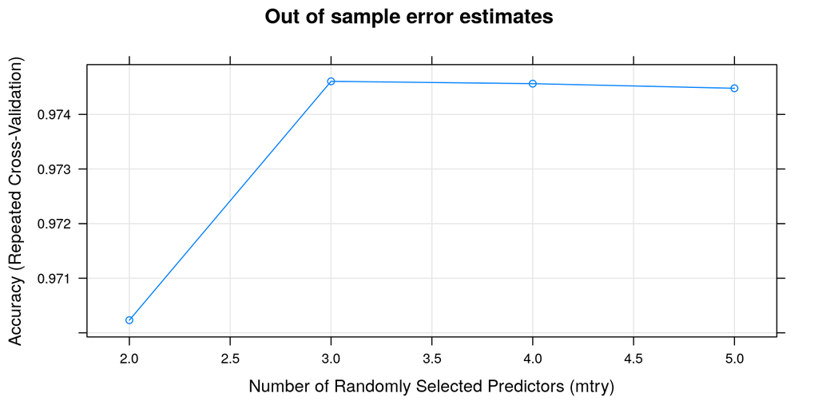

Figure 4.1: The plot shows the cross validation estimates for the out of sample error for different values of the model parameter ‘mtry’.

The estimated accuracy of the trained model with the optimal value *mtry* = 3 is better than 97%. In the following we calculate the accuracy on the data we held back for validation.

```r
# Predic class for validation data
valPred <- predict(mdl1,train.data.tst)
valCM <- confusionMatrix(train.data.tst$classe,valPred)

print(valCM$overall)
```

```
##       Accuracy          Kappa  AccuracyLower  AccuracyUpper   AccuracyNull
##   0.9750191180   0.9683919830   0.9696398169   0.9796738751   0.2867703288
## AccuracyPValue  McnemarPValue
##   0.0000000000   0.0004178702
```

The accuracy of around 98% of the model predictions on the validation data is comparable to the accuracy estimates from the cross validation. This gives us some confidence that the model does not have a problem with overfitting.

Finally, let us check how the accuracy depends on the number of trees in the random forest model. In Figure 4.2 the error rate and accuracy of the model is plotted as a function of the number of trees.

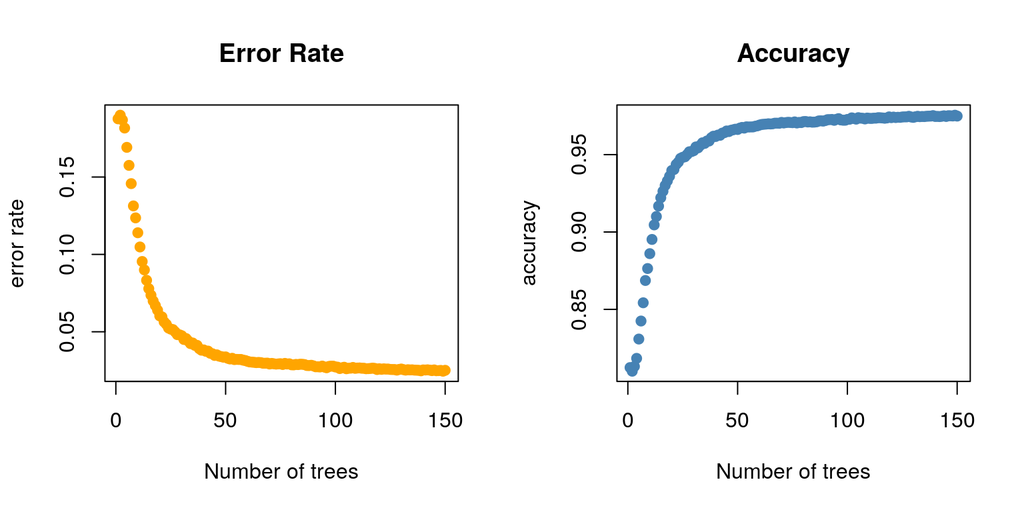

Figure 4.2: Error rate (left) and accuracy (right) for the trained model as a function of the number of trees.

# 5 Predicting

Once the model is trained, predicting the class variable “classe” for the test data is straightforward. After preparing the test data using the PCA one can use the *predict* function of the caret package.

```r
# Get testing data from PCA
pcaTest <- data.frame(predict(pca, testing))
pcaTest <- pcaTest[,1:idx]
pcaTest <- data.frame(c(testing[,c("user_name","new_window")],pcaTest))

cPredict <- predict(mdl1,pcaTest)
print(cPredict)
```

```
##  [1] B A B A A E D B A A B C B A E E A B B B
## Levels: A B C D E
```

As it turns out when this result is submitted to the prediction quiz on the course homepage, the accuracy of this prediction is 100%.

# References

[1] E. Velloso, A. Bulling, H. Gellersen, W. Ugulino, and H. Fuks, in *Proceedings of the 4th Augmented Human International Conference* (ACM, 2013), pp. 116–123.